# Ecological Archives M082-007-A9

*Ecological Archives* M082-007-A9

Thomas W. Baribault, Richard K. Kobe, and Andrew O. Finley. 2012. Tropical tree growth is correlated with soil phosphorus, potassium, and calcium, though not for legumes. *Ecological Monographs* 82:189–203. http://dx.doi.org/10.1890/11-1013.1

Appendix I. Mean basal area increment at the site level for individual species.

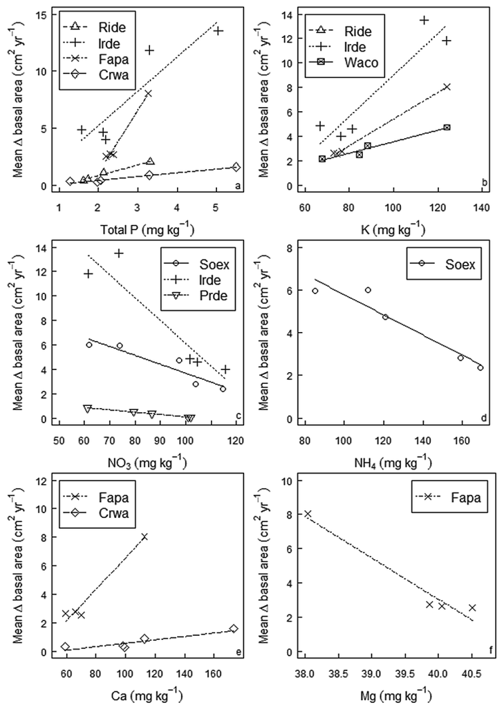

Fig. I1. Site-mean basal area increment for individual species as a function of soil resources. Growth was positively related to P, Ca, and K, but negatively related to NO<sub>3</sub>, NH<sub>4</sub>, and Mg. For species with growth related to more than one resource, the same symbol and line type are used in all relevant panels. See Table D6 for model parameters and goodness of fit assessment. Uncertainty associated with estimating resource availability is presented in Fig. I2–I10.

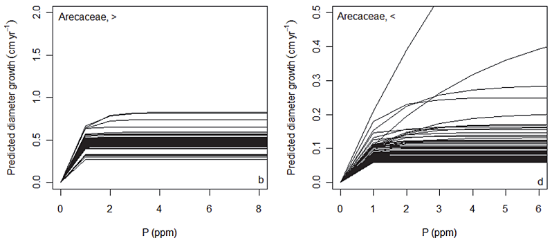

Fig. I2. Predicted individual diameter growth based on 101 estimated soil resource datasets plotted against total soil P (b, d) for the Arecaceae. Total soil P explained 7.9% total growth variance for subcanopy (>) species, and 6.0% total growth variance for treelet and understory species (<).

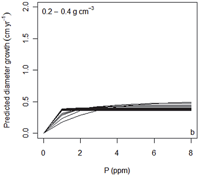

Fig. I3. Predicted diameter growth based on 101 estimated soil resource datasets plotted as a function of total soil P for species with lowest wood density (0.2–0.4 g cm<sup>-3</sup>).

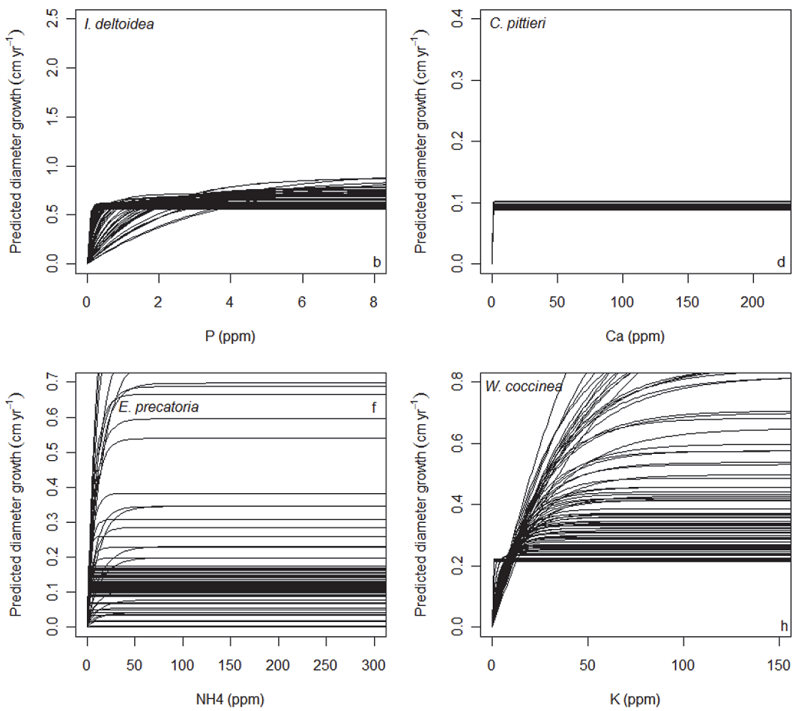

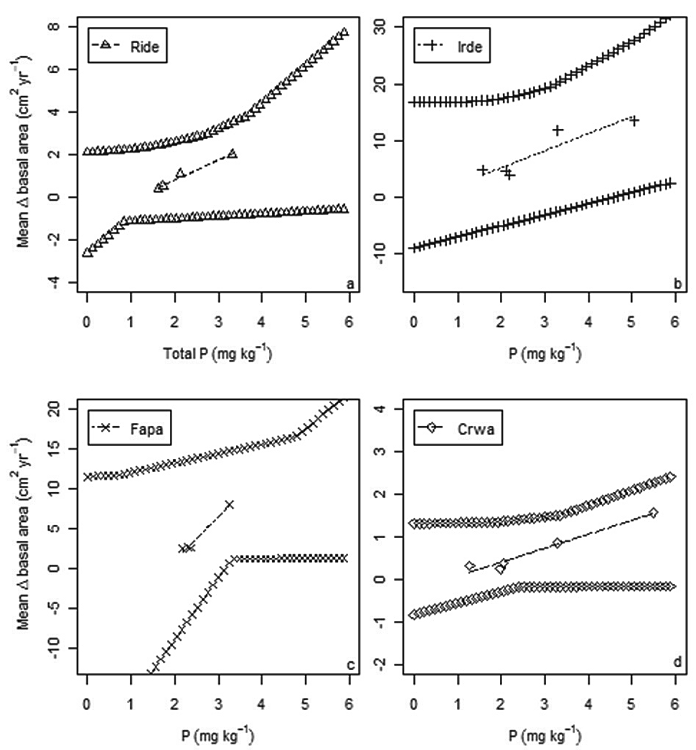

Fig. I5. Uncertainty envelopes (maximum and minimum) based on resource estimation procedure for individual species for which site mean basal area increment was related to total soil P. Results correspond to Fig. 5.3a.

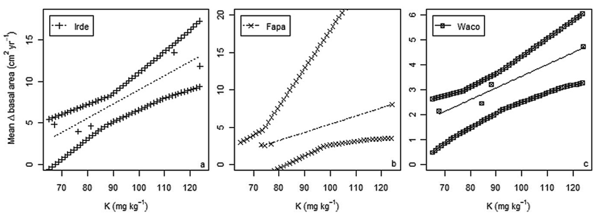

[figure not shown]

Fig. I6. Uncertainty envelopes (maximum and minimum) based on resource estimation procedure for individual species for which site mean basal area increment was related to soil K. Results correspond to Fig. 5.3b.

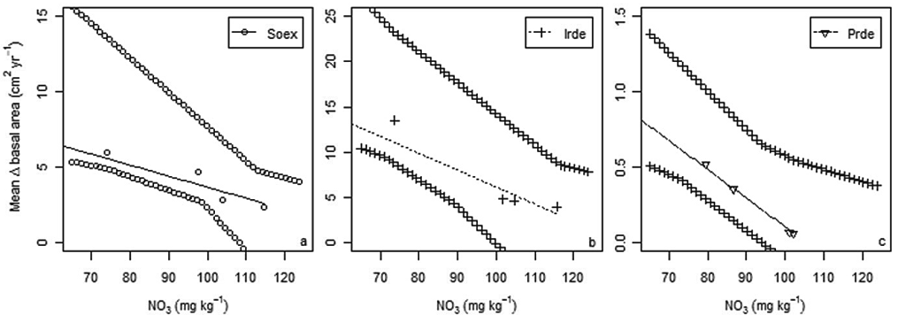

Fig. I7. Uncertainty envelopes (maximum and minimum) based on resource estimation procedure for individual species for which site mean basal area increment was related to soil NO<sub>3</sub>. Results correspond to Fig. 5.3c.

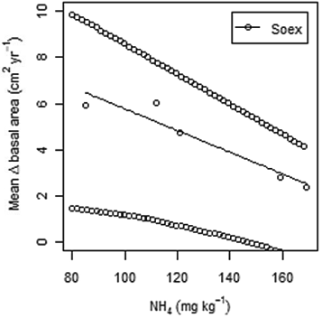

Fig. I8. Uncertainty envelopes (maximum and minimum) based on resource estimation procedure for *S. exorrhiza*, for which site mean basal area increment was related to soil NH<sub>4</sub>. Result corresponds to Fig. 5.3d.

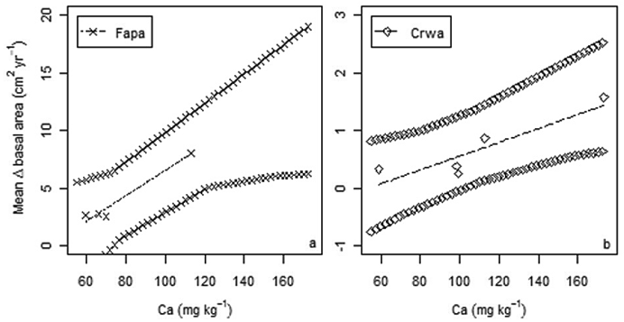

Fig. I9. Uncertainty envelopes (maximum and minimum) based on resource estimation procedure for individual species for which site mean basal area increment was related to soil Ca. Result corresponds to Fig. 5.3e.

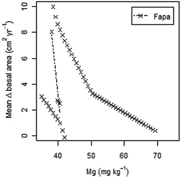

[Back to M082-007]